# ggChap5: Toolbox

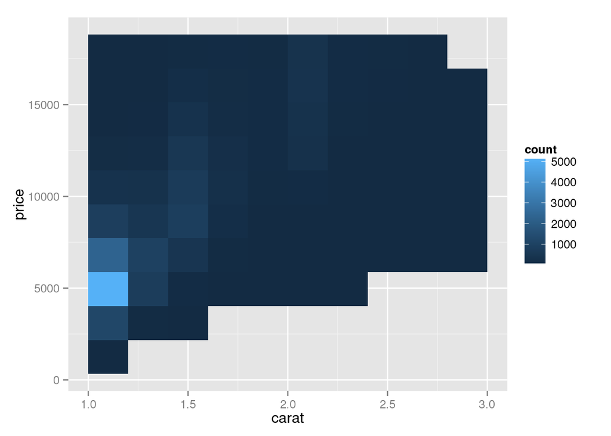

```r
d + stat_bin2d(bins = 10)
```

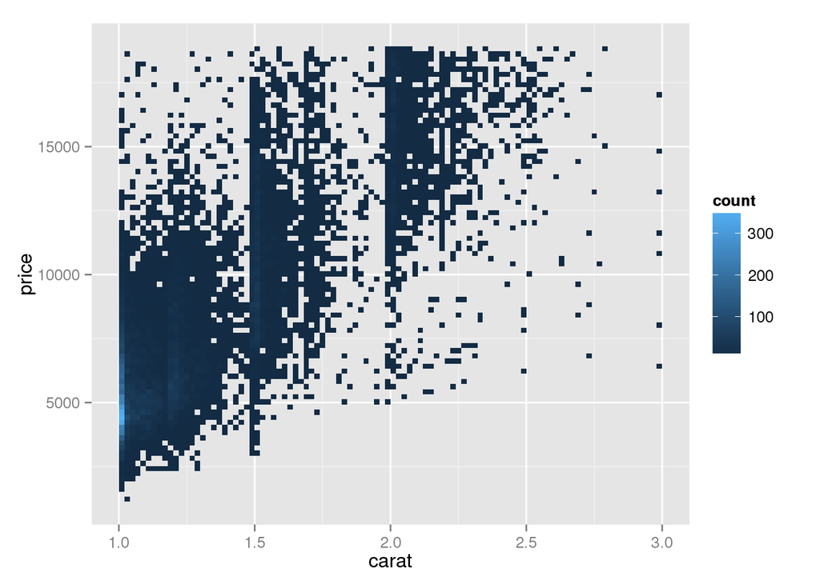

```r
d + stat_bin2d(binwidth=c(0.02, 200))
```

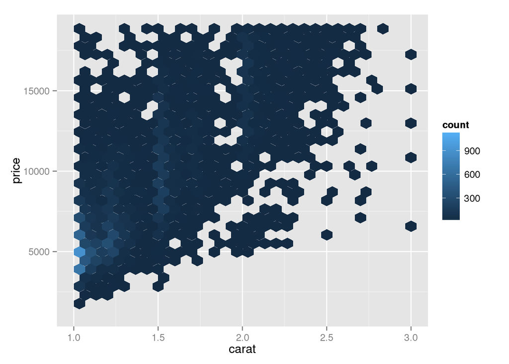

```r
d + stat_binhex()
```

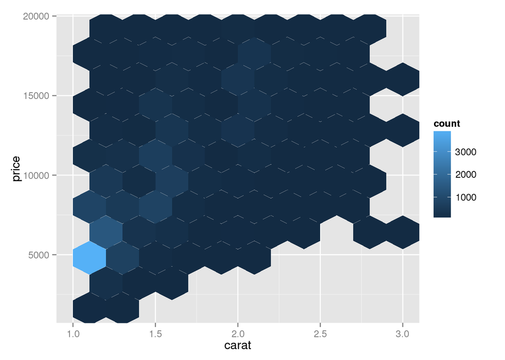

```r
d + stat_binhex(bins = 10)
```

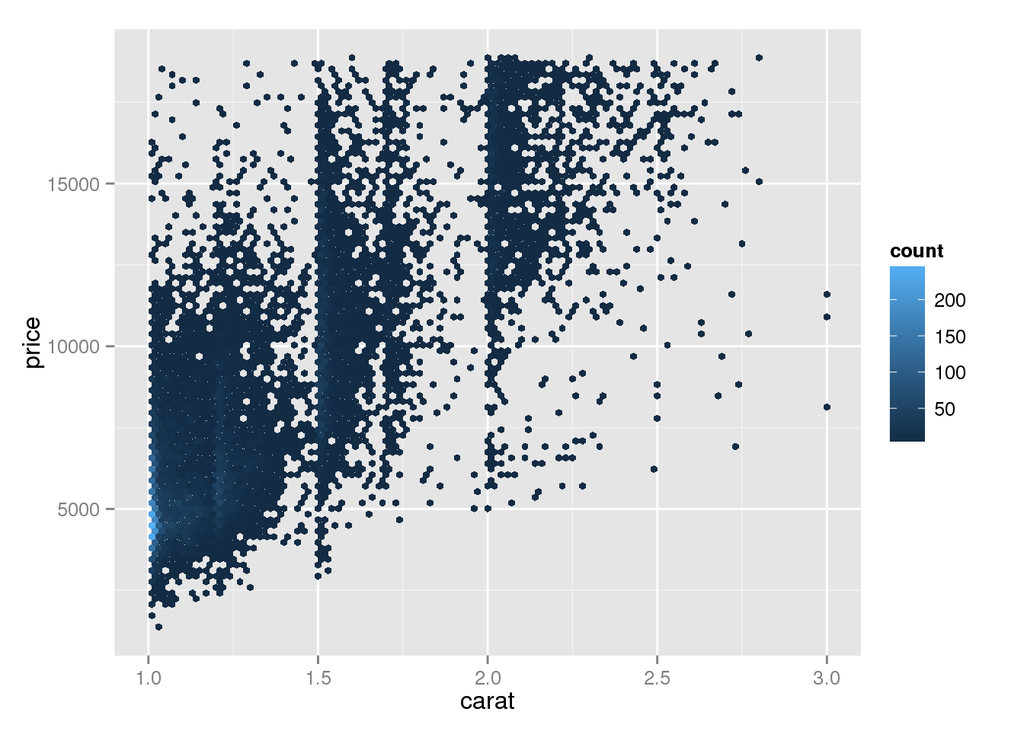

```r
d + stat_binhex(binwidth=c(0.02, 200))
```

- Estimate the 2d density with stat_density2d, and overlay contours from this distribution on the scatterplot, or display the density by itself as coloured tiles, or points with size proportional to density.

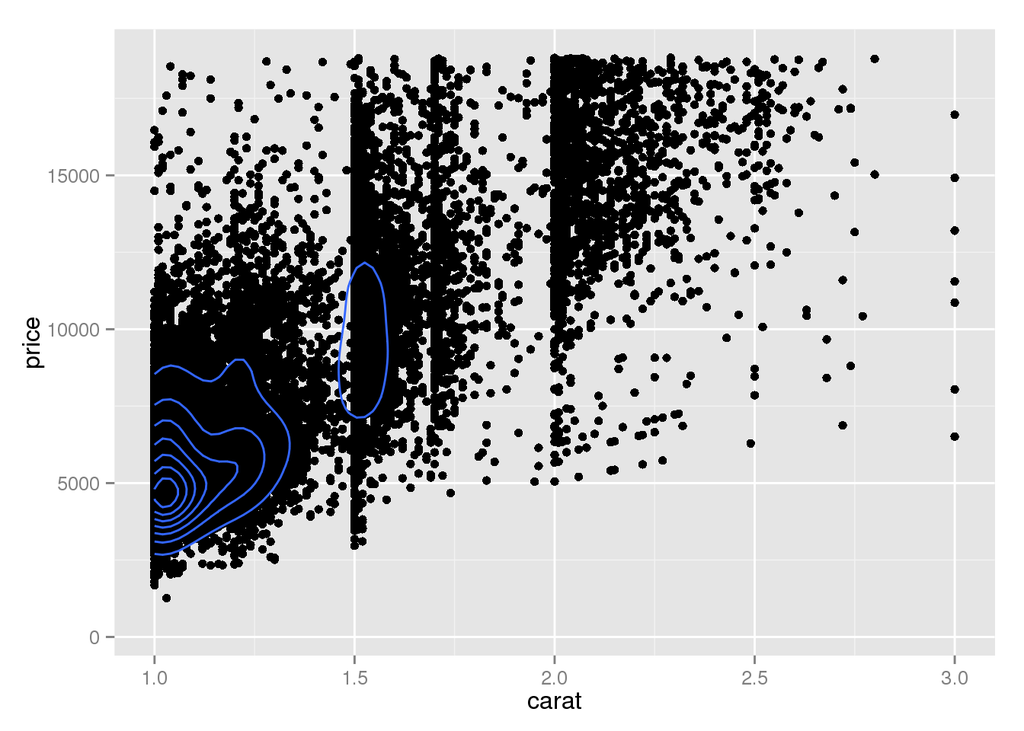

```r
d <- ggplot(diamonds, aes(carat, price)) + xlim(1,3)
d + geom_point() + geom_density2d()
```

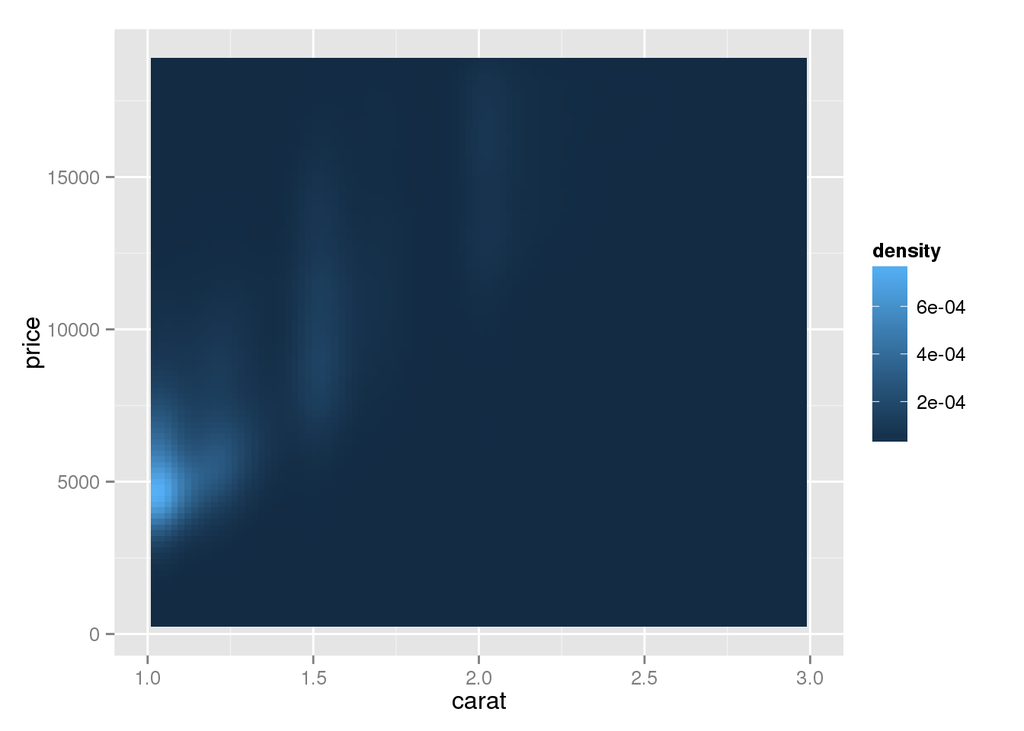

```r
# d + stat_density2d(geom = "point", aes(size = ..density..), contour = F) +
#   scale_size_area(to = c(0.2, 1.5))
d + stat_density2d(geom = "tile", aes(fill = ..density..), contour = F)
```

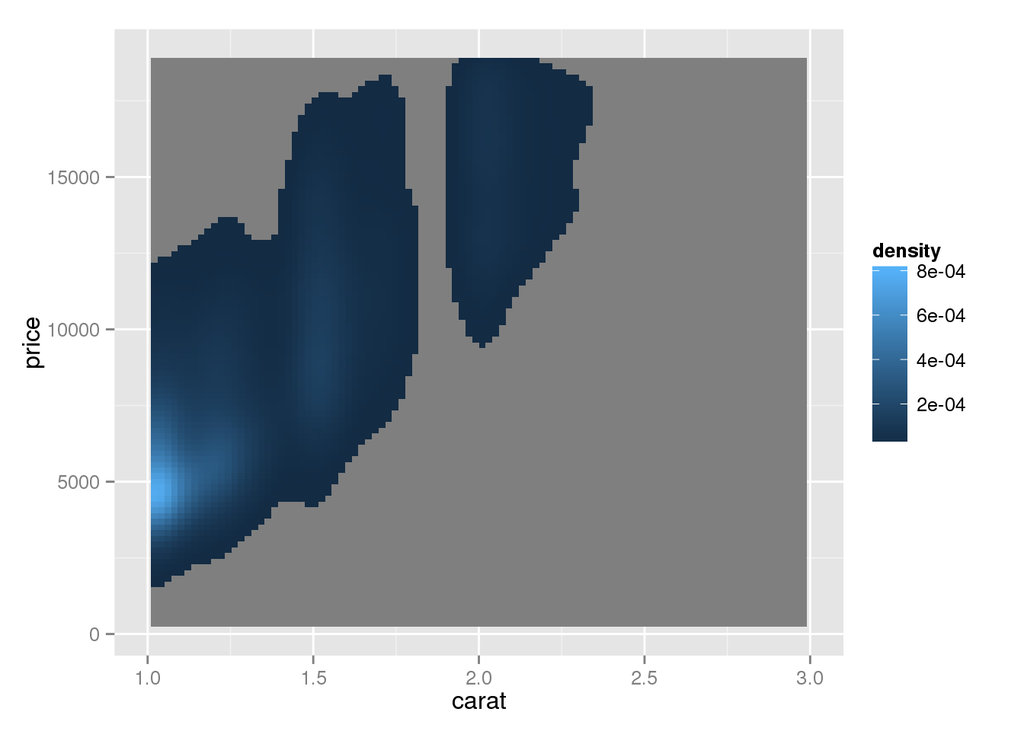

```r
last_plot() + scale_fill_gradient(limits = c(1e-5,8e-4))
```

Another approach to dealing with overplotting is to add data summaries to help guide the eye to the true shape of the pattern within the data. For example, you could add a smooth line showing the centre of the data with `geom_smooth`.

## 5.6 Surface plots

`ggplot2` currently does not support true 3d surfaces. However, it does support the common tools for representing 3d surfaces in 2d: contours, coloured tiles and bubble plots.

## 5.7 Drawing maps

ggplot2 provides some tools to make it easy to combine maps from the `maps` package with other ggplot2 graphics.

There are two basic reasons you might want to use map data:

- to add reference outlines to a plot of spatial data,
- to construct a choropleth map by filling regions with colour.

Adding map border is performed by the `borders()` function. The first two arguments select the map and region within the map to display. The remaining arguments control the appearance of the borders: their `colour` and `size`. If you’d prefer filled polygons instead of just borders, you can set the fill colour.

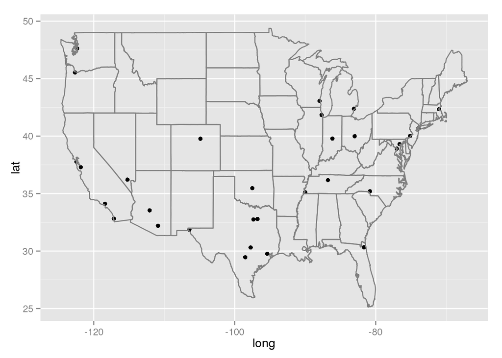

```r
library(maps)
data(us.cities)
big_cities <- subset(us.cities, pop > 500000)
qplot(long, lat, data = big_cities) + borders("state", size = 0.5)
```

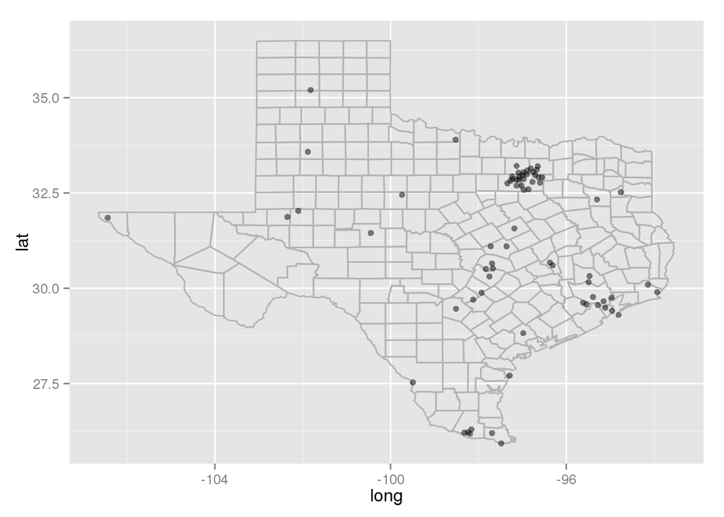

```r
tx_cities <- subset(us.cities, country.etc == "TX")
ggplot(tx_cities, aes(long, lat)) +
  borders("county", "texas", colour = "grey70") +
  geom_point(colour = alpha("black", 0.5))
```

Choropleth maps are a little trickier and a lot less automated because it is challenging to match the identifiers in your data to the identifiers in the map data. The following example shows how to use `map_data()` to convert a map into a data frame, which can then be `merge()`d with your data to produce a choropleth map.

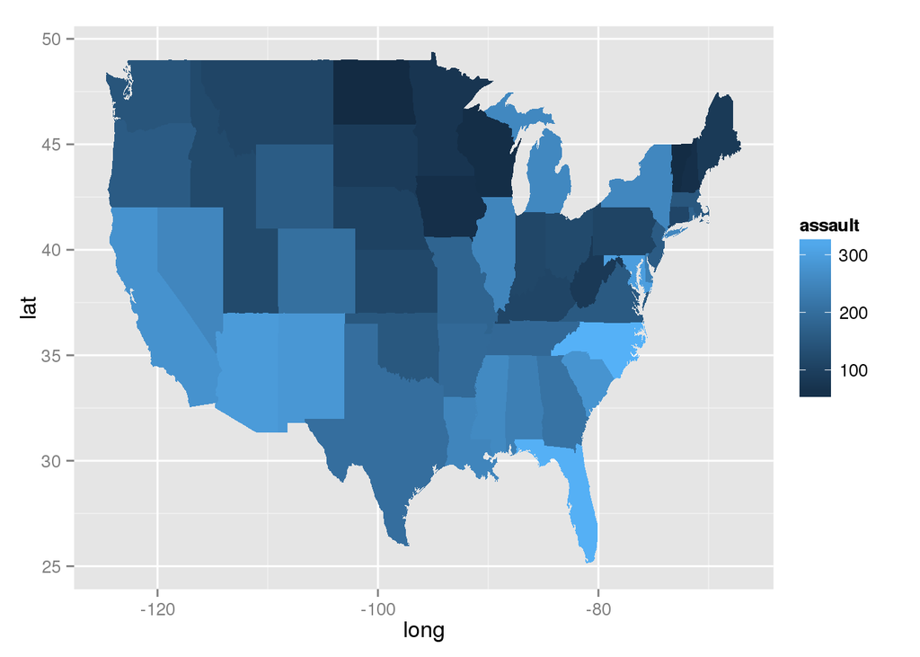

```r
library(maps)
states <- map_data("state")
arrests <- USArrests
names(arrests) <- tolower(names(arrests))
arrests$region <- tolower(rownames(USArrests))
choro <- merge(states, arrests, by = "region")
# Reorder the rows because order matters when drawing polygons
# and merge destroys the original ordering
choro <- choro[order(choro$order), ]
qplot(long, lat, data = choro, group = group,fill = assault, geom = "polygon")
```

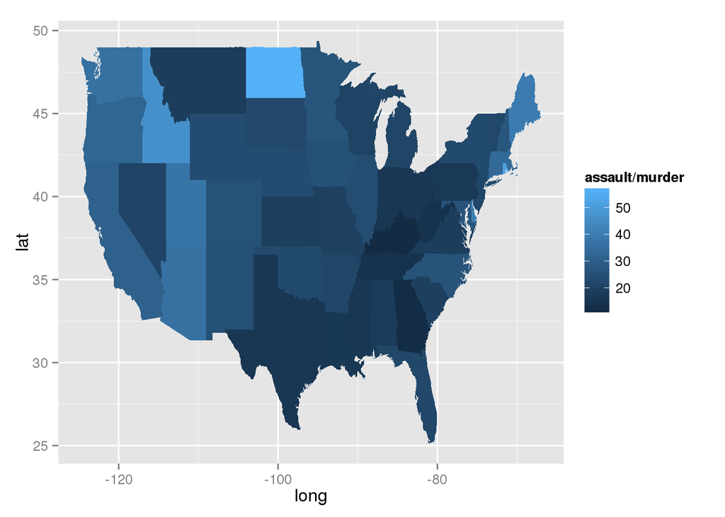

```r
qplot(long, lat, data = choro, group = group,
      fill = assault / murder, geom = "polygon")
```

## 5.8 Revealing uncertainty

If you have information about the uncertainty present in your data, whether it be from a model or from distributional assumptions, it is often important to display it. There are four basic families of geoms that can be used for this job, depending on whether the x values are discrete or continuous, and whether or not you want to display the middle of the interval, or just the extent.

```r
d <- subset(diamonds, carat < 2.5 & + rbinom(nrow(diamonds), 1, 0.2) == 1)
d$lcarat <- log10(d$carat)
d$lprice <- log10(d$price)
# Remove overall linear trend
detrend <- lm(lprice ~ lcarat, data = d)
d$lprice2 <- resid(detrend)
mod <- lm(lprice2 ~ lcarat * color, data = d)
library(effects)
effectdf <- function(...) {
  suppressWarnings(as.data.frame(effect(...)))
  }
color <- effectdf("color", mod)
```

```
## NOTE: color is not a high-order term in the model
```

```r
both1 <- effectdf("lcarat:color", mod)
carat <- effectdf("lcarat", mod, default.levels = 50)
```

```
## NOTE: lcarat is not a high-order term in the model
```

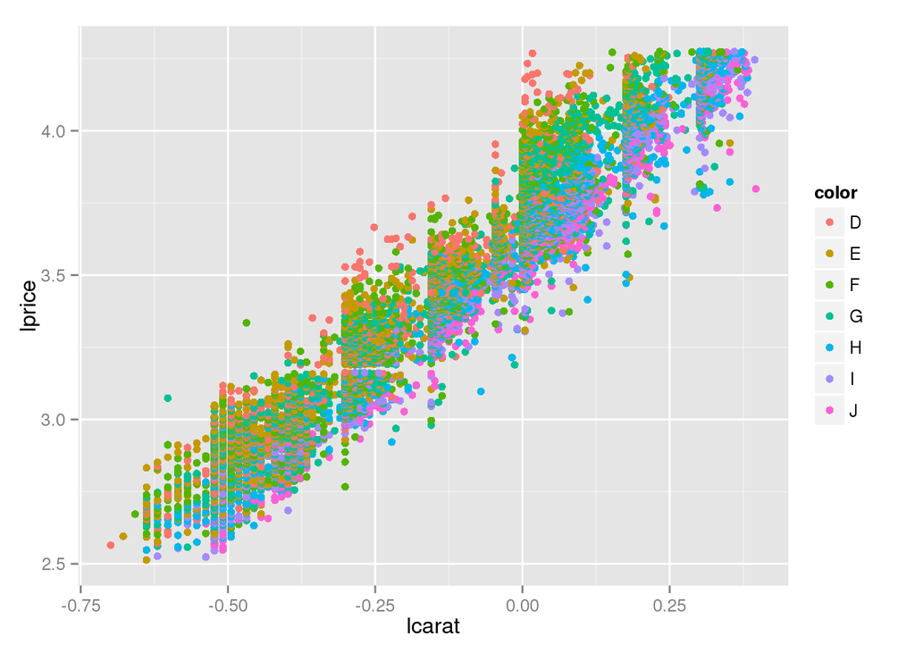

```r
both2 <- effectdf("lcarat:color", mod, default.levels = 3)
qplot(lcarat, lprice, data=d, colour = color)
```

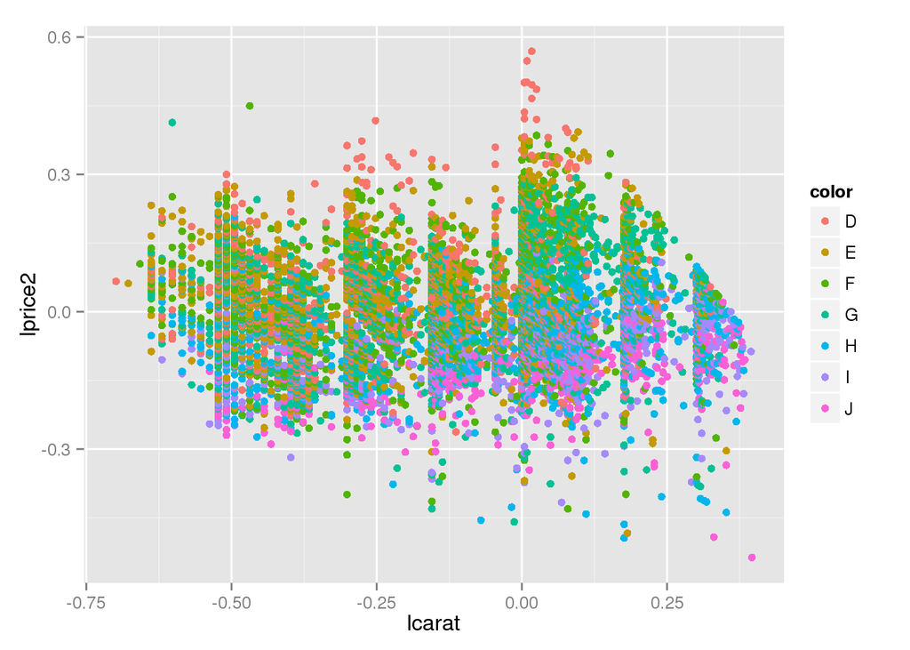

```r
qplot(lcarat, lprice2, data=d, colour = color)
```

## 5.9 Statistical summaries

It’s often useful to be able to summarise the y values for each unique x value. In ggplot2, this role is played by `stat_summary()`, which provides a flexible way of summarising the conditional distribution of y with the aesthetics `ymin`, `y` and `ymax`.

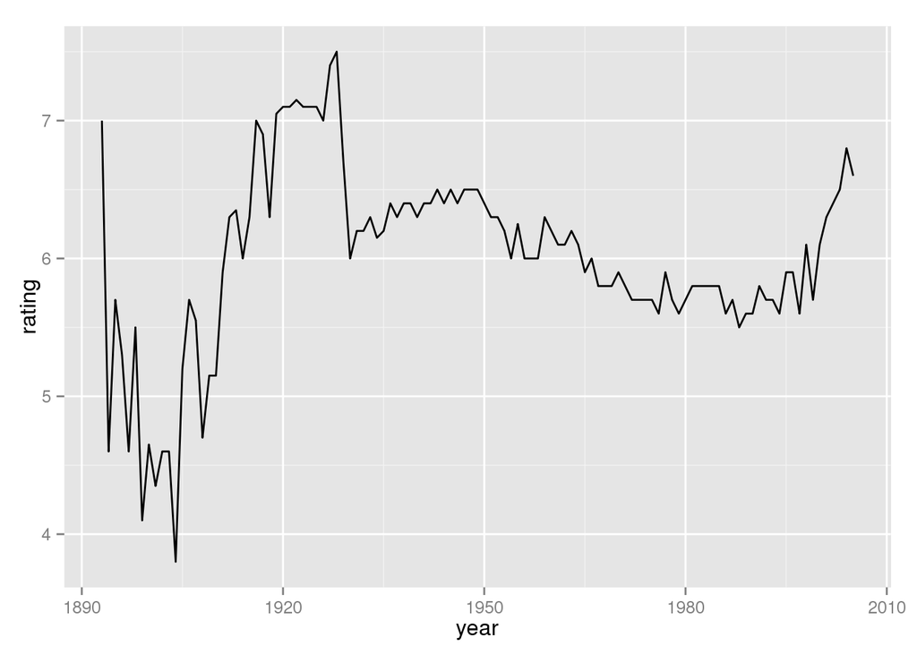

```r
m <- ggplot(movies, aes(year, rating))
m + stat_summary(fun.y = "median", geom = "line")
```

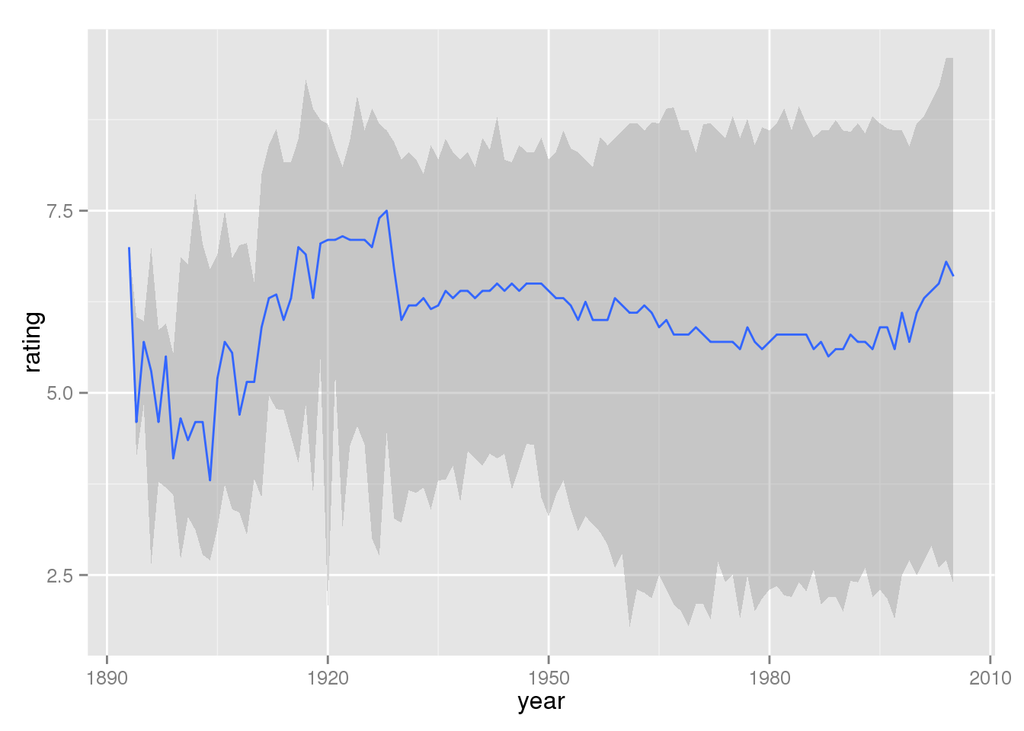

```r
m + stat_summary(fun.data = "median_hilow", geom = "smooth")
```

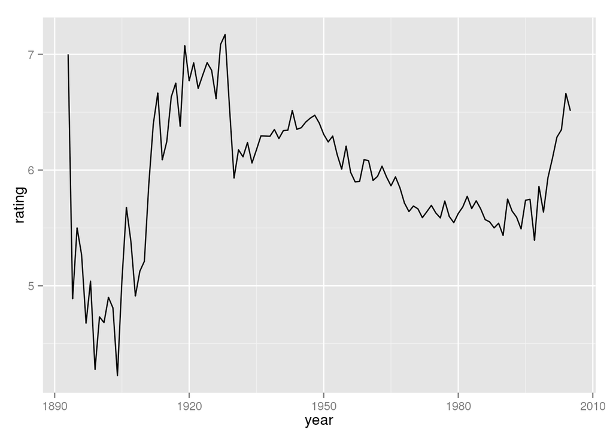

```r
m + stat_summary(fun.y = "mean", geom = "line")
```

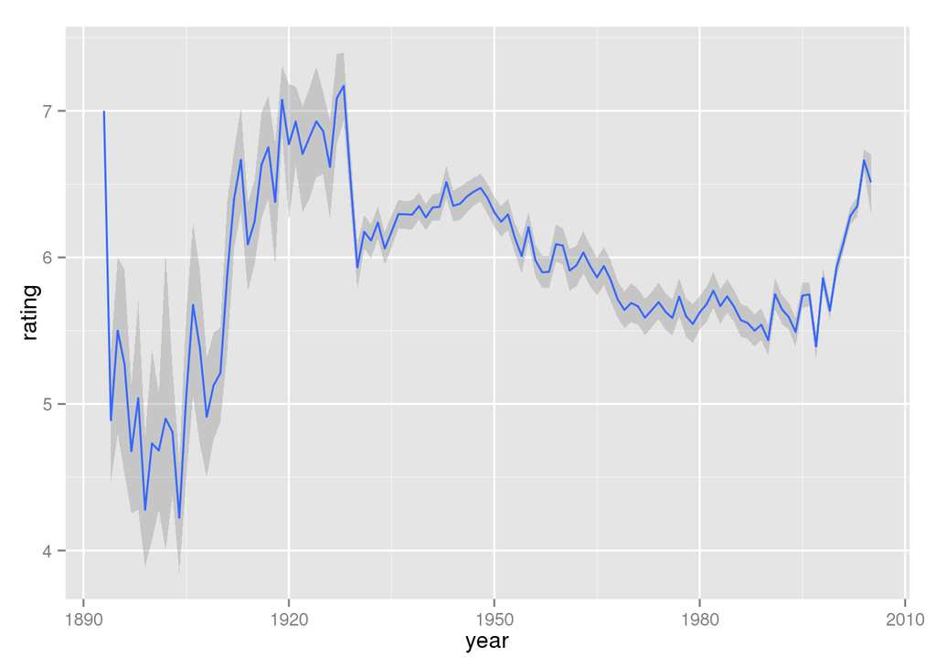

```r
m + stat_summary(fun.data = "mean_cl_boot", geom = "smooth")
```

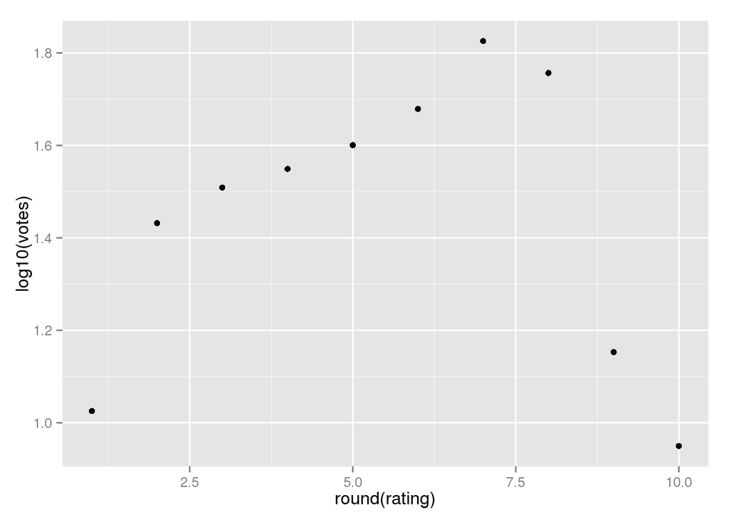

```r
m2 <- ggplot(movies, aes(round(rating), log10(votes)))
m2 + stat_summary(fun.y = "mean", geom = "point")
```

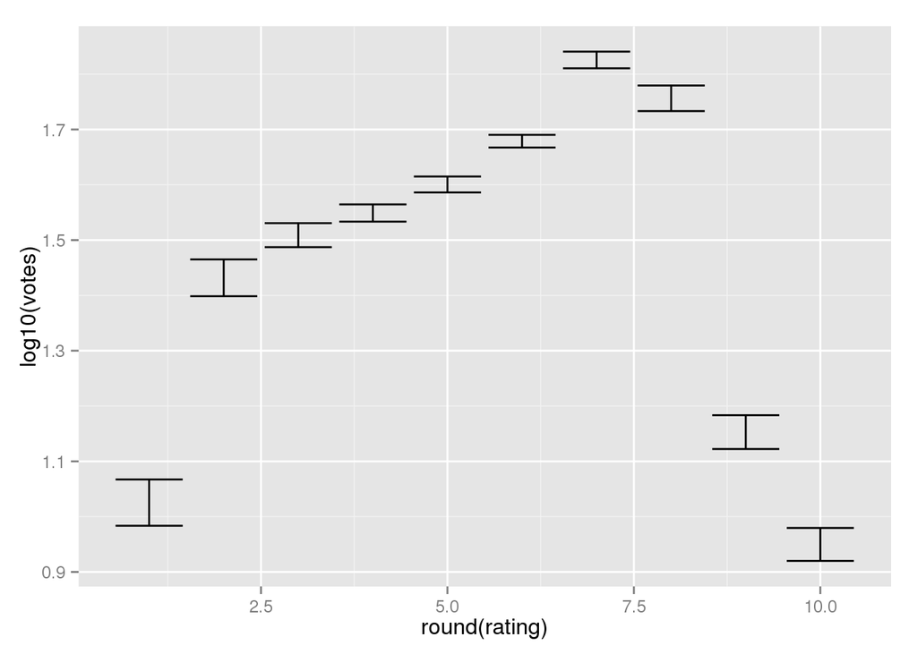

```r
m2 + stat_summary(fun.data = "mean_cl_normal", geom = "errorbar")
```

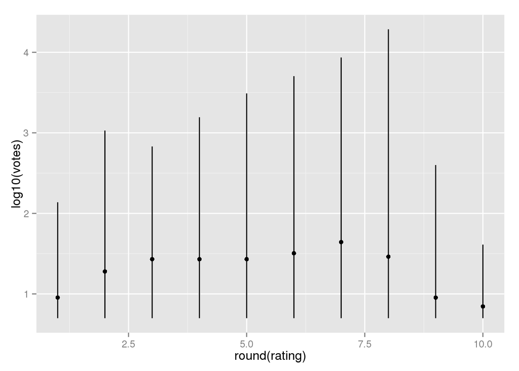

```r
m2 + stat_summary(fun.data = "median_hilow", geom = "pointrange")
```

```r
# m2 + stat_summary(fun.data = "median_hilow", geom = "crossbar")
```

### 5.9.1 Individual summary functions

The arguments `fun.y`, `fun.ymin` and `fun.ymax` accept simple numeric summary functions. You can use any summary function that takes a vector of numbers and returns a single numeric value: mean(), median(), min(), max().

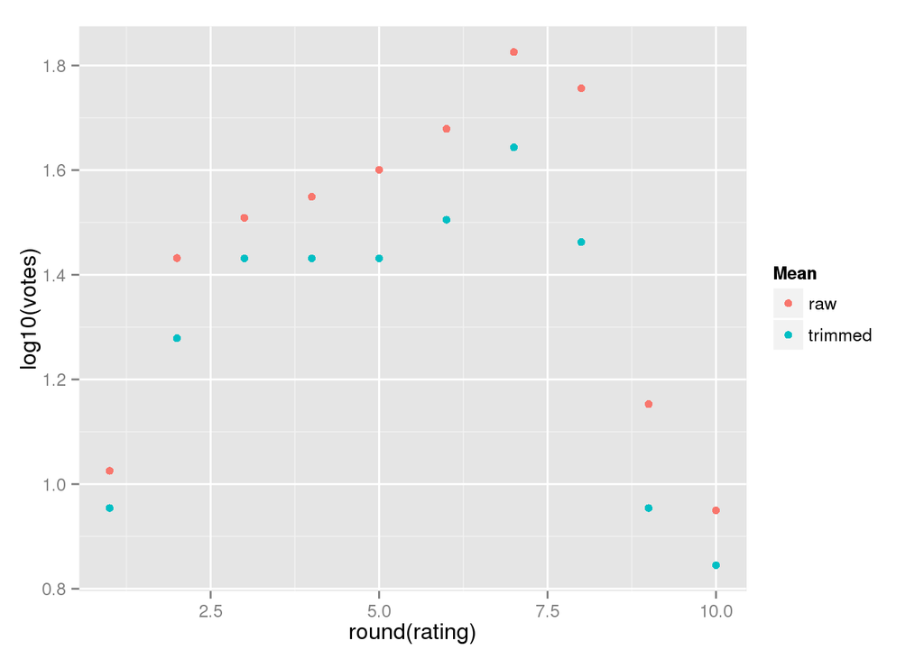

```r
midm <- function(x) mean(x, trim = 0.5)
m2 +
  stat_summary(aes(colour = "trimmed"), fun.y = midm, geom = "point") +
  stat_summary(aes(colour = "raw"), fun.y = mean, geom = "point") +
  scale_colour_hue("Mean")
```

### 5.9.2 Single summary function

`fun.data` can be used with more complex summary functions such as one of the summary functions from the `Hmisc` package. You can also write your own summary function. This summary function should return a named vector as output.

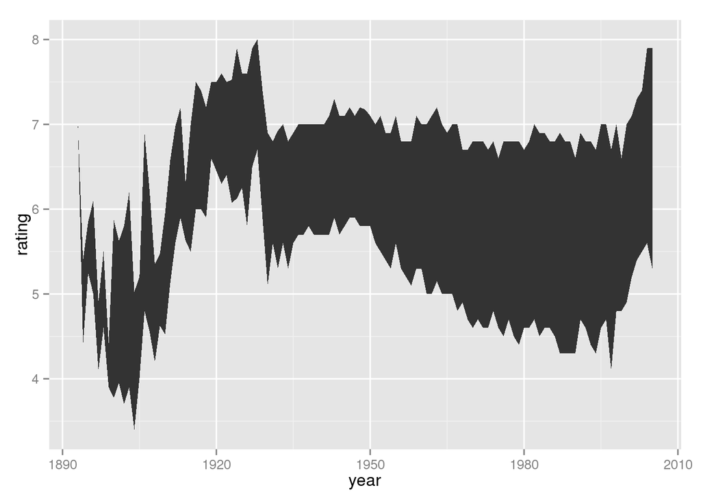

```r
iqr <- function(x, ...) {
  qs <- quantile(as.numeric(x), c(0.25, 0.75), na.rm = T)
  names(qs) <- c("ymin", "ymax")
  qs
}
m + stat_summary(fun.data = "iqr", geom="ribbon")
```

## 5.10 Annotating a plot